# Socioeconomic Inequality and Its Impact on Child Survival in Myanmar

The Su Moe

2025-07-03

# Introduction

Myanmar is a lower-middle-income country located in Southeast Asia that continues to face social and economic challenges. Although there has been progress in improving child and maternal health, many children still face unequal chances of survival. Factors like poverty, low levels of education, and living in rural areas make it harder for families to access healthcare. As a result, child mortality remains higher among disadvantaged groups. Reducing these inequalities is key to improving child health outcomes nationwide. [Reference](https://pmc.ncbi.nlm.nih.gov/articles/PMC6507915)

[figure not shown]

*Photo from www.alamy.com

# Aims

- To explore the relationship between household wealth and child mortality.
- To evaluate the effect of maternal education and rural-urban residence on child survival.

# Findings

## Child Mortality Rate by Wealth Index and Education

Table: Child Mortality Rate by Wealth and Education

| highest educational level | wealth index combined | ChildMortalityRate | Count |
| --- | --- | --- | --- |
| no education | poorest | 0.33523538 | 701 |
| no education | poorer | 0.29708223 | 377 |
| no education | middle | 0.32644628 | 242 |
| no education | richer | 0.19337017 | 181 |
| no education | richest | 0.25274725 | 91 |
| primary | poorest | 0.20551181 | 1,270 |
| primary | poorer | 0.18469861 | 1,294 |
| primary | middle | 0.14930271 | 1,219 |
| primary | richer | 0.13310962 | 894 |
| primary | richest | 0.09734513 | 452 |
| secondary | poorest | 0.09424084 | 382 |
| secondary | poorer | 0.07104558 | 746 |
| secondary | middle | 0.07062147 | 1,062 |
| secondary | richer | 0.04575646 | 1,355 |
| secondary | richest | 0.03634957 | 1,293 |
| higher | poorest | 0.00000000 | 11 |
| higher | poorer | 0.02941176 | 34 |
| higher | middle | 0.04587156 | 109 |
| higher | richer | 0.01298701 | 308 |
| higher | richest | 0.01972158 | 862 |
|  | middle | 0.00000000 | 1 |
|  | richer | 1.00000000 | 1 |

## Child Mortality by Wealth Index

As shown in the Figure 1, there is a clear reverse relationship between household wealth and child mortality in Myanmar. As household wealth increases, the proportion of women who experienced the death of a child decreases: around 25% of women experienced child mortality in the poorest group. In contrast, in the richest group, this proportion drops to less than 5%. This finding suggests that economic disadvantage is strongly associated with higher risk of child death, highlighting the need for targeted health interventions and support for low-income households.

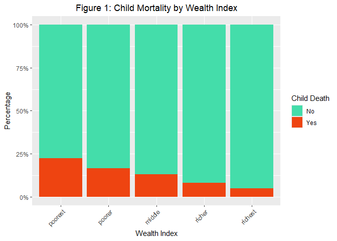

## Child Mortality by Maternal Education

As shown in the Figure 2, there is a strong negative association between maternal education and child mortality: Women with no education have the highest proportion of child mortality, at around 30%. As education level increases, child mortality decreases sharply. Women with primary education had a noticeably lower risk (~20%) of child mortality and for Secondary and higher education, mortality is very low, at around 5% or less. This pattern clearly shows that higher maternal education acts as a protective factor against child mortality. It likely reflects better knowledge of health practices, improved access to healthcare, and greater autonomy in health decision-making.

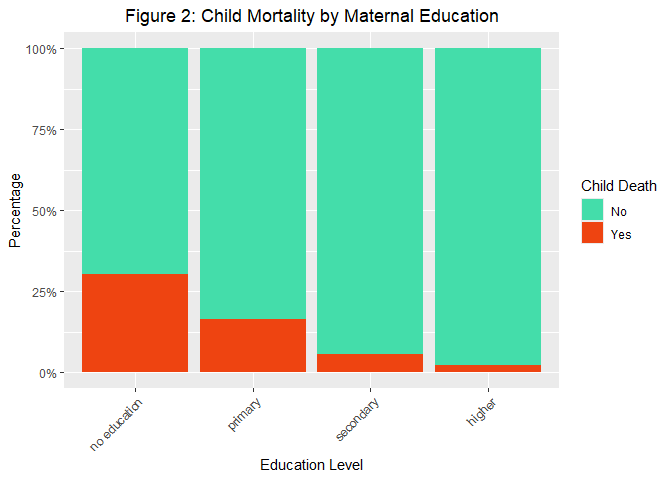

## Child Mortality by Electricity Access

Figure 3 reveals that there is a significant correlation between electricity access and child survival, showing that households with electricity experience approximately half the child mortality rate (around 10%) compared to those without electricity (roughly 20%). This finding highlights the crucial role of electricity access, likely contributing to improved living conditions and better access to healthcare and essential services, in reducing child mortality.

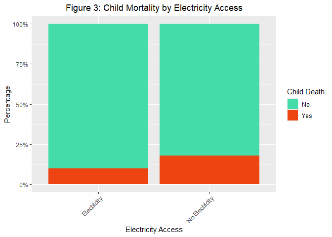

## Child Mortality by Urban vs Rural Residence

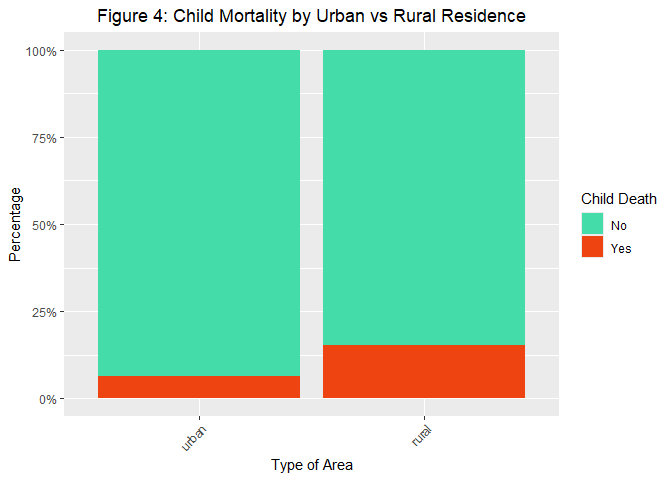

## Child Mortality by Maternal Age Group

Figure 5 indicates a clear trend of child mortality rates which increase with the age of the mother. For mothers aged 15-19, child mortality is very low (less than 1%), but it steadily rises, reaching its highest proportion among mothers aged 45-49, where roughly 28% of mothers experienced the death of a child. This suggests that older maternal age is associated with a higher likelihood of child mortality.

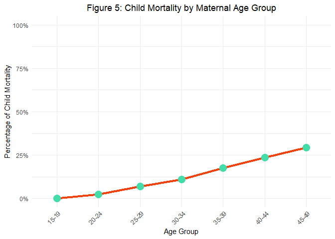

# Conclusion

The findings clearly demonstrate that child mortality in Myanmar is strongly associated with socioeconomic factors such as maternal education, household wealth, electricity access, and urban-rural residence. Higher levels of maternal education and household wealth consistently correlate with lower child mortality rates, highlighting education and economic empowerment as critical protective factors. Additionally, households with electricity and those located in urban areas exhibit significantly lower child mortality, emphasizing the role of infrastructure and access to services. Lastly, maternal age plays an important role, with older mothers experiencing higher rates of child death. These results underscore the urgent need for targeted interventions that address structural inequalities to improve child survival outcomes.